# Intro to Phylogenetics

2022-06-02

## Building Trees

This discussion will cover basic ways to construct and compare trees. First, we’ll have to set up our R environment to use both `DECIPHER` and `ape` (a package that helps up visualize trees in R).

```r
# Package imports
library(ape)
library(DECIPHER)
source('./TreeLine.R')

# Helper plotting function
plot_tree_unrooted <- function(dend, title){
  tf <- tempfile()
  WriteDendrogram(dend, file=tf, quoteLabels=FALSE)
  predTree <- read.tree(tf)
  plot(predTree, 'unrooted', main=title)
}
```

### Distance Matrices

Most phylogenetic reconstruction algorithms rely upon constructing distance matrices. There are a variety of way to do this, but for purposes of illustration we’ll be using the simplest method.

Let’s construct a toy dataset for purposes of illustration:

```r
sequenceSet <- DNAStringSet(c('AGACT',
                              'AGACG',
                              'TCATT',
                              'TGCTG',
                              'AGCTG'))
names(sequenceSet) <- 1:5
```

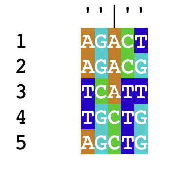

For each pair of sequences, we count the proportion of residues that do not match and mark this as the distance between them. As an example of calculating distance, consider the first two sequences in this set:

$$\begin{align*}
&1)\;\;&AGACT&\\
&2)\;\;&AGACG&
\end{align*}$$

Since these sequences differ at 1 out of 5 total residues, their distance is $\frac{1}{5}=0.2$.

We can quickly calculate a complete distance matrix between these sequences with the following:

```r
dm <- DistanceMatrix(sequenceSet, type='dist', verbose=F)
dm
```

```
##     1   2   3   4   5
## 1 0.0 0.2 0.6 0.8 0.6
## 2 0.2 0.0 0.8 0.6 0.4
## 3 0.6 0.8 0.0 0.6 0.8
## 4 0.8 0.6 0.6 0.0 0.2
## 5 0.6 0.4 0.8 0.2 0.0
```

Notice that the distance between 1 and 2 is 0.2, just as we calculated before. Now we can begin to create trees.

### UPGMA/WPGMA

The simplest tree building method is the Unweighted Pair Group Method with Arithmetic Means (UPGMA). This is a hierarchical clustering algorithm that sequentially builds a tree from the bottom up. The algorithm begins with a distance matrix, and proceeds in the following steps:

1. Identify the pair of nodes with the lowest distance $d_{min}$. Here I’ve multiplied the distances by 10 to make it easier to read (it doesn’t make a difference in the final result).
2. Create a new node $N_{new}$ that joins these pairs of nodes, and create branch lengths such that each leaf is equidistant from $N_{new}$ The total branch length should from the $N_{new}$ to any leaf should be half of $d_{min}$. In this case, $d_{min} = 2$ and our new node is called $u$.
3. Combine the two rows of the distance matrix into one row by replacing each pair of entries with their average. The average is weighted by the number of leaves in each pair being combined, so if the two rows are each clusters with multiple leaves, the average should be weighted accordingly.

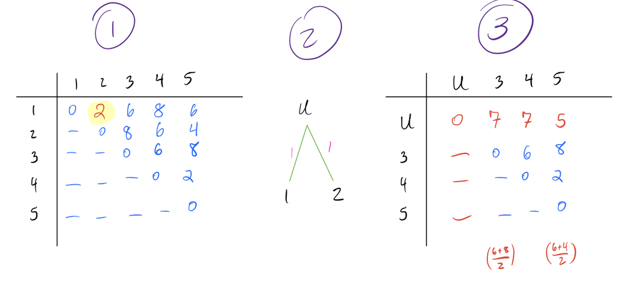

4. Repeat above steps until all nodes are combined and the distance matrix is a single row and column.

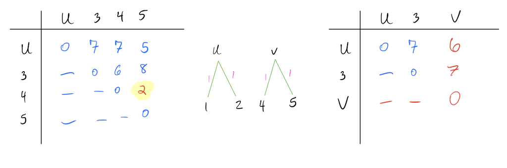

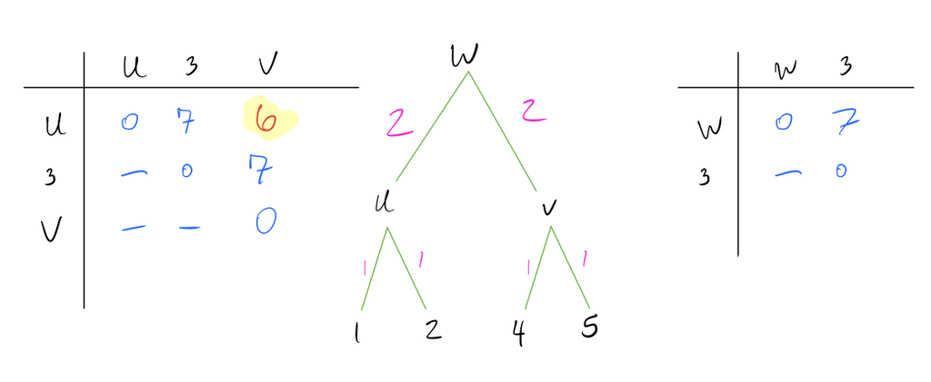

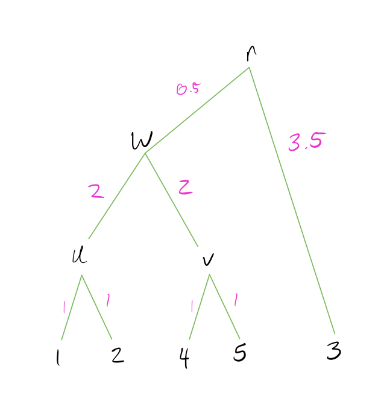

Note that UPGMA methods always create an ultrametric tree, which means the tree is rooted and all leaves are equidistant from the root. This implies a molecular clock (rate of mutation is the same across all lineages of a tree).

We can create a UPGMA tree in R with the below commands. Note that R doubles the lengths obtained by this, so I’m going to multiply the distance matrix by 5 to get the same scale factor as the example worked through above.

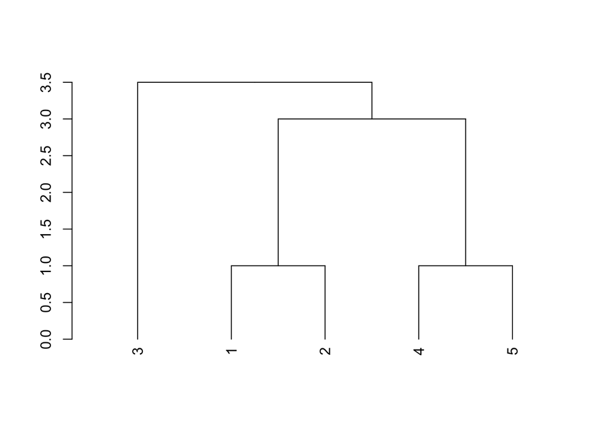

```r
# UPGMA Tree
dend <- as.dendrogram(hclust(dm*5, method='average'))
plot(dend)
```

A variation of UPGMA is WPGMA, where W stands for ‘weighted’. The difference between UPGMA and WPGMA is a bit counter-intuitive. Recall that when we combine two rows of the distance matrix in UPGMA, we weight our average by the number of leaves in the node being combined. In WPGMA, we do **not** weight by number of leaves in the node, and instead treat each node as having equal weight.

As an example, consider the following distance matrix:

$$\begin{matrix}
& n_1 & n_2 & n_3 \\
n_1 & 0 & 3 & 5 \\
n_2 & - & 0 & 3 \\
n_3 & - & - & 0 \\
\end{matrix}$$

Now suppose that node $n_1$ has 10 leaves, node $n_2$ has 2 leaves, and node $n_3$ has 1 leaf. If we wanted to combine nodes $n_1$ and $n_2$ into node $u$ using UPGMA, the distance from $u$ to $n_3$ would be calculated with the following formula:

$$\begin{align*}
d_{UPGMA}(u, n_3) &= \frac{1}{|n_1| + |n_2|} \left(|n_1|*d(n_1,n_3)
+ |n_2|*d(n_2,n_3) \right)\\
&= \frac{1}{10+2} \left(10*5 + 2*3 \right)
&= 4.67
\end{align*}$$

However, if we combined these with WPGMA, we would instead ignore the number of leaves in each cluster and just take the simple arithmetic average, as follows:

$$\begin{align*}
d_{WPGMA}(u, n_3) &= \frac{1}{2} \left(d(n_1,n_3) + d(n_2,n_3)
\right)\\
&= \frac{1}{2} \left(5 + 3 \right)
&= 4
\end{align*}$$

You’re probably wondering, “why does *weighted* PGMA use *unweighted* combinations and vice-versa?” The answer lies in what we’re referring to when we talk about pair combinations being (un)weighted. Since UPGMA weights each node by the number of leaves, it’s correcting for nodes representing clades of difference sizes. In other words, the combination is inherently weighted, and UPGMA uses a clever way to “undo” this combination. WPGMA, by contrast, does not weight by clade size, and thus the combinations are biased (weighted) by the number of leaves in each nodes.

Implementing WPGMA trees is very similar to UPGMA trees (and gives the same result in this example):

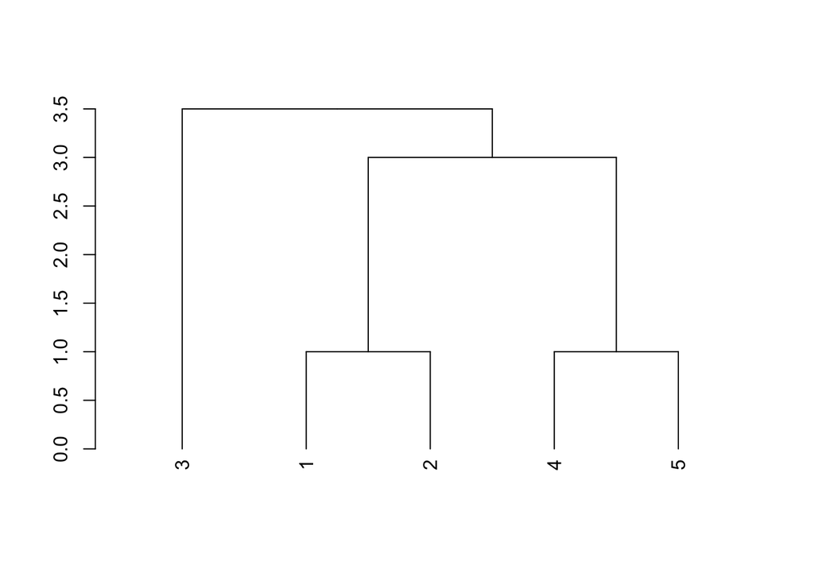

```r
# WPGMA Tree
dend <- as.dendrogram(hclust(dm*5, method='mcquitty'))
plot(dend)
```

There are also other methods for combining the distance matrices–see the help page for `hclust` for other examples.

### Neighbor Joining Trees

Another common approach to building trees is the Neighbor-Joining (NJ) method. This method also utilizes distance matrices, but proceeds from the top-down rather than UPGMA’s bottom-up approach. We’ll use the same distance matrix (multiplied by 10 as before for simpler visualization). The algorithm proceeds in the following steps:

1. Start with a star tree (all connected to a single root node), and record the row and column sums for each row/column of the matrix.

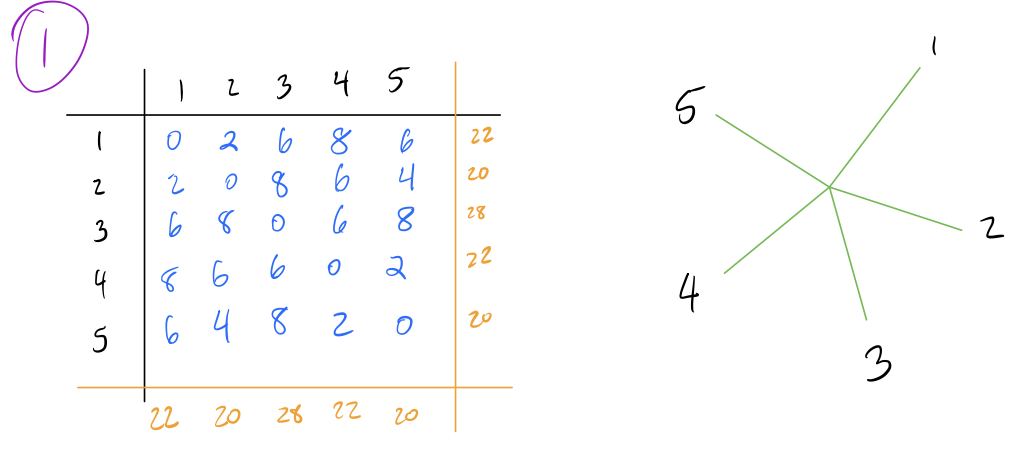

2. Create a Q-matrix, which is a matrix of the same dimensions as the distance matrix, and each element given by the following formula:

$$Q[i,j] = (n-2)d(i,j) - R(i) -
C(j)$$

Here $n$ is the number of nodes under consideration (the number of  
rows of the distance matrix), $d(i,j)$ is the distance from node $i$  
to node $j$, $R(i)$ is the sum of the $i$’th row, and $C(j)$ is the sum  
of the $j$’th column.

3. Identify the smallest pair $f,g$ in the Q-matrix, and combine the corresponding nodes by adding an intermediate node $N_{int}$ between them in the tree.

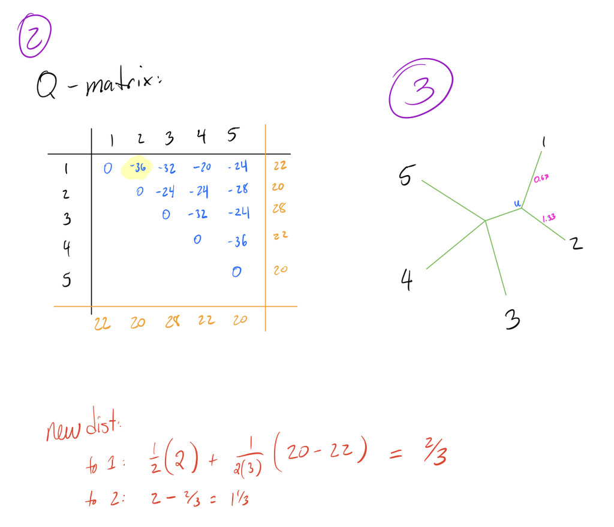

4. Calculate edge lengths from $N_{int}$ to $f,g$ with the following formula:

$$\begin{align*}
d(N_{int}, f) &= \frac{1}{2}(d[i,j]) + \frac{1}{2(n-2)}(R(i) -
C(j))\\
d(N_{int}, g) &= d[i,j] - d[N_{int}, f]
\end{align*}$$

5. Calculate distance from $N_{int}$ to all other nodes $h$ with the following formula:

$$d(h, N_{int}) = \frac{1}{2}(d[h,g] +
d[h,f] - d[f,g])$$

6. Repeat until the full tree has been constructed.

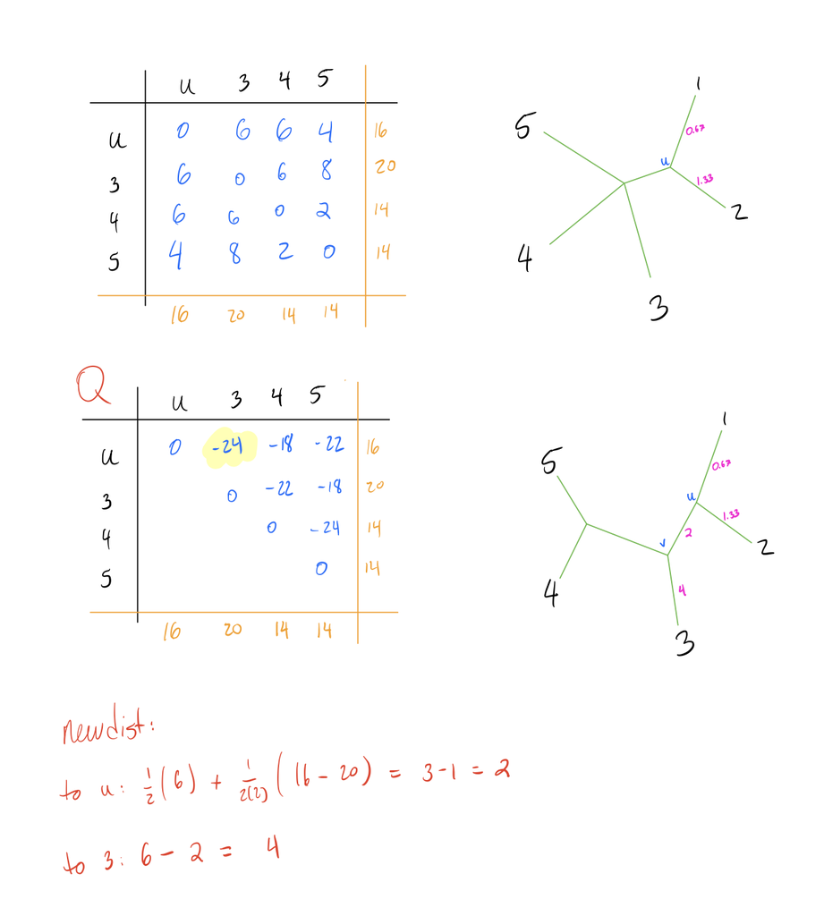

We can do this in the exact same way as before.

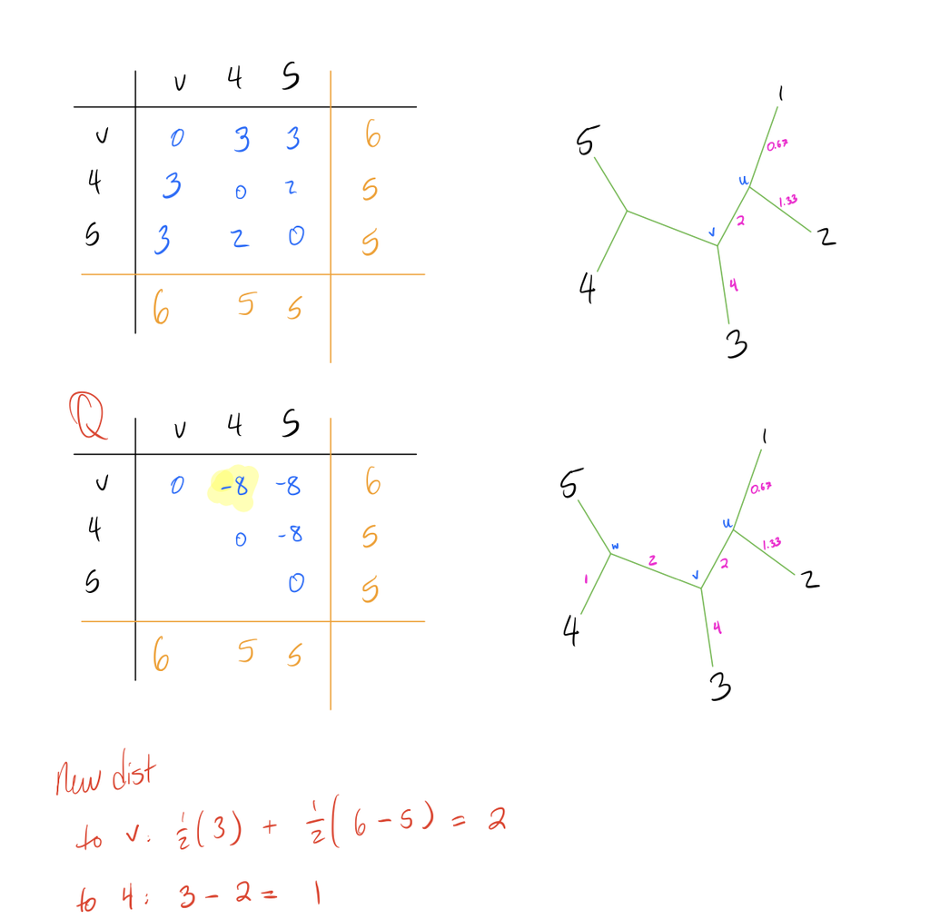

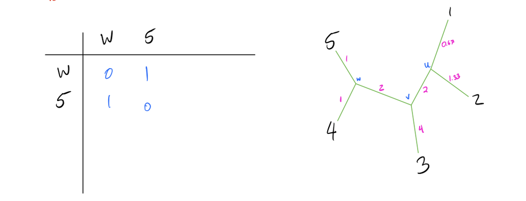

This can be done in R with the following commands. Note that the output is slightly different due to a different method for calculating the initial distance matrix.

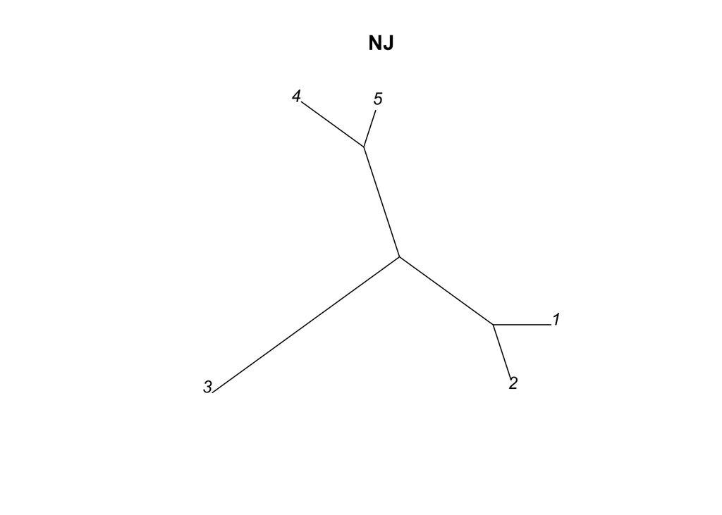

```r
dend <- TreeLine(myDistMatrix=dm, method='NJ')
plot_tree_unrooted(dend, 'NJ')
```

### Maximum Parsimony Trees

The last way to construct phylogenies that I will discuss is maximum parsimony. This method relies on the assumption that the simplest method is likely the best, and thus tries to find a tree that minimizes the number of changes on the tree. Such a tree is called the most “parsimonious” tree.

To illustrate what this looks like, we’ll look at a subset of our initial set of sequences. I’ve also included a distance matrix corresponding to the number of state transitions required to switch from one sequence to another (the Hamming distance).

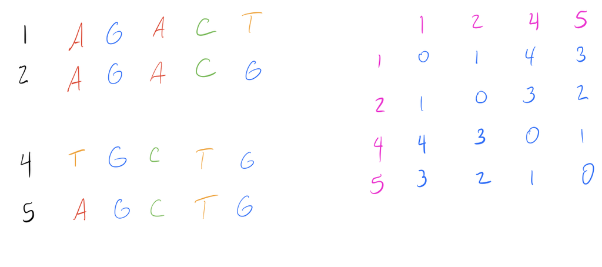

Notice how sequences 1 and 2 are very similar, and sequences 4 and 5 are very similar. An optimal reconstruction would place sequences 1 and 2 close together and sequences 4 and 5 close together, since these pairs require the fewer transitions to convert between. For a set of 4 nodes, we have four possible topologies:

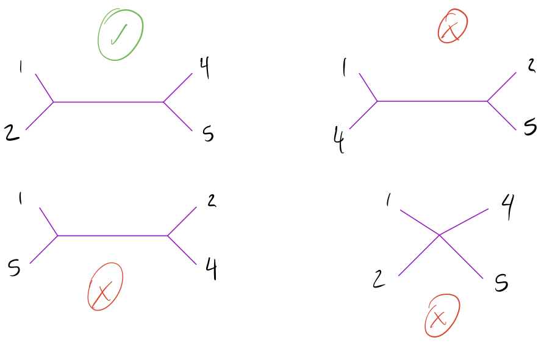

Three of these are trees with a single internal branch, and one is a star tree with no branches. The top left tree is the most parsimonious, because it minimizes the transition cost along any particular path of the tree.

Parsimony tree reconstructions don’t use distance matrices, and instead randomly walk through tree space to find a tree that is most parsimonious. A purely random strategy would take eons to complete, so modern methods use various optimizations. Common techniques include iteratively adding branches to maximize parsimony with each branch added, and/or perturb trees by performing nearest neighbor interchanges (NNIs). NNIs take a quartet in the tree and swap the partition to check if a rearrangement is more parsimonious. An example of an NNI would be taking any of the quartets in the previous graphic and checking if any of the other types are more parsimonious.

We can do maximum parsimony reconstructions in R using the following code:

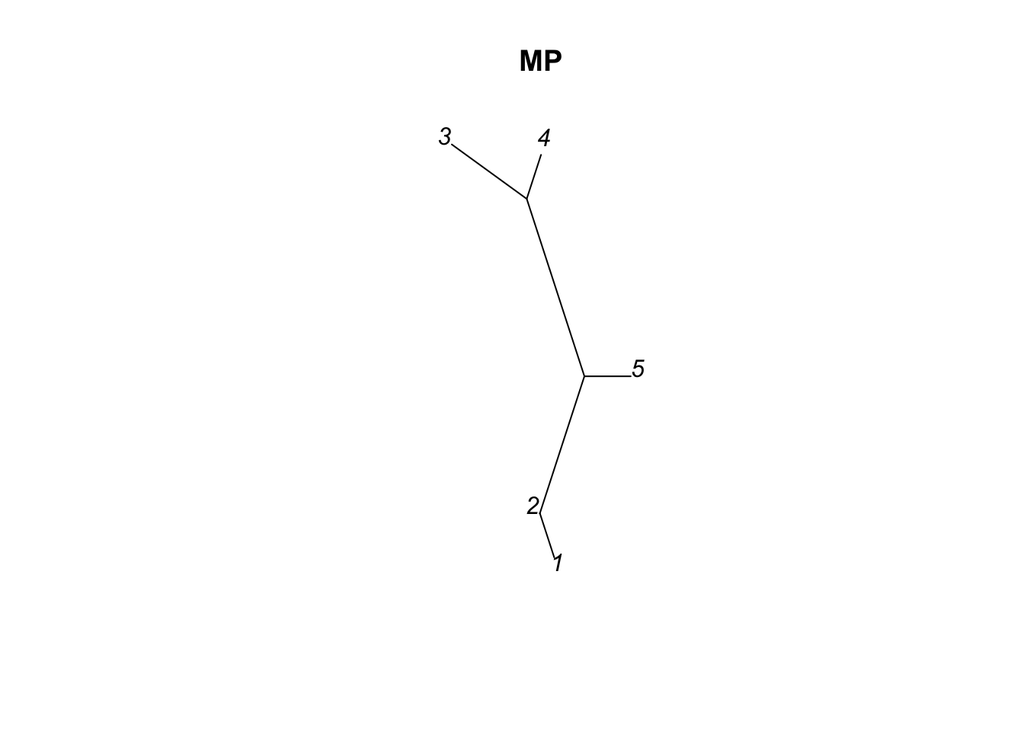

```r
dend <- TreeLine(sequenceSet, method='MP')
plot_tree_unrooted(dend, 'MP')
```

## Comparing Trees

Making trees is nice, but how do we compare them? Comparing trees is a difficult problem, since they can contain significantly different topologies.

In this discussion I’ll cover two common ways of calculating distances between trees: Robinson-Foulds (RF) Distance and Kuhner-Felsenstein (KF) distance.

### Setup

We’ll start with a slightly larger test dataset so that we can more clearly see differences between tree constructions. The following codeblocks read in a set of 25 simulated alignments, then constructs phylogenetic trees using the three methods discussed previously.

```r
# External data file, contains simulated alignment
simSeqsFile <- './Simulated_v1.fas'

simAli <- suppressWarnings(readDNAStringSet(simSeqsFile))[1:25]
names(simAli) <- 1:25
simDm <- DistanceMatrix(simAli, type='dist', penalizeGapGapMatches=FALSE, verbose=FALSE)

UPGMAtree <- as.dendrogram(hclust(simDm, method='average'))
NJtree <- TreeLine(simAli, myDistMatrix=simDm, method='NJ')
MPtree <- TreeLine(simAli, myDistMatrix=simDm, method='MP')
```

Visualizing the trees we’ve made:

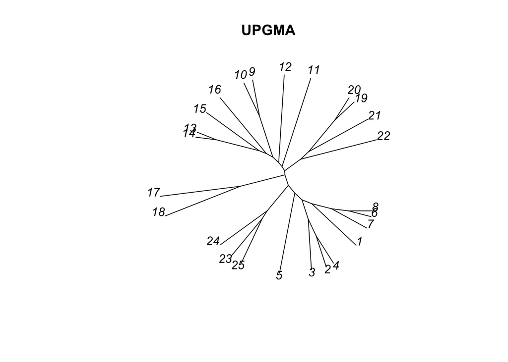

```r
plot_tree_unrooted(UPGMAtree, 'UPGMA')
```

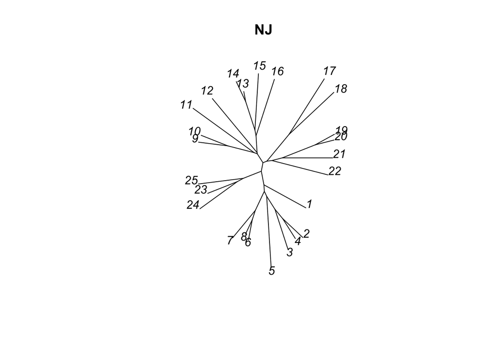

```r
plot_tree_unrooted(NJtree, 'NJ')
```

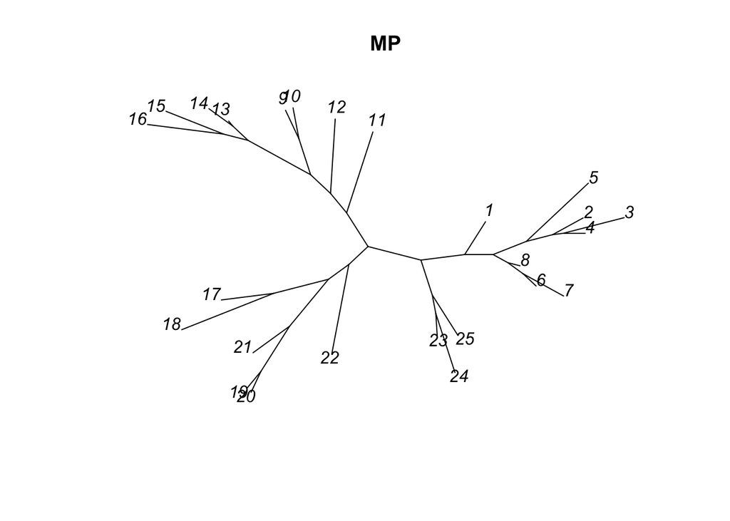

```r
plot_tree_unrooted(MPtree, 'MP')
```

### Partitions

Before we dive into tree distances, it’s important to understand the concept of partitions. In a bifurcating unrooted tree, every edge divides the set of leaf nodes into two sets. These form the basis of many tree comparison algorithms. Let’s look at a toy example:

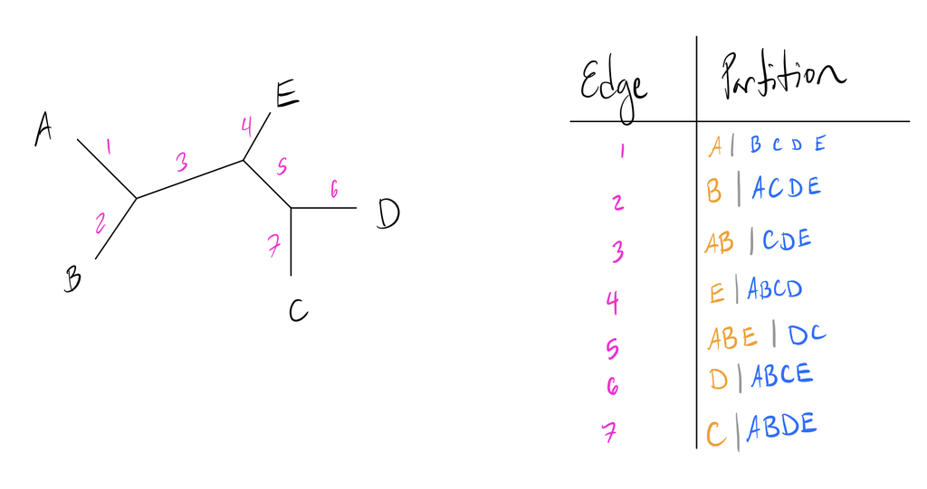

Note how each numbered edge of the tree splits the labeled leaf nodes into two distinct groups to either side of it. Leaf edges trivially split the tree into a partition of just the leaf and everything else, but internal edges split the leaves into more interesting partitions.

### RF Distance

Robinson-Foulds (RF) distance measures the similarity of these partitions in a tree. Let’s look at a toy example with two small trees and their internal partitions labeled (internal edges circled in green):

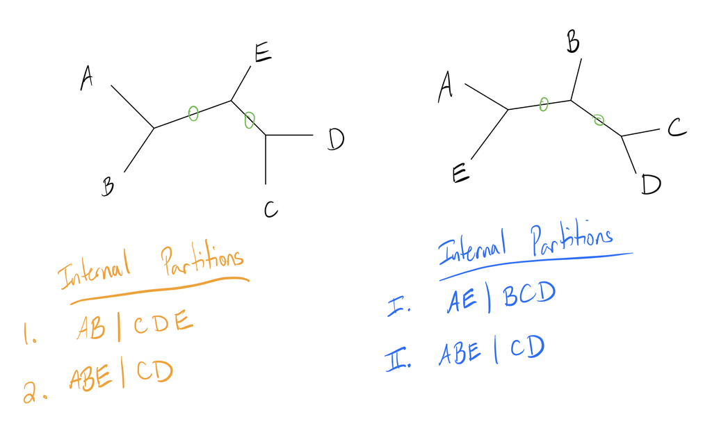

Now let $A$ be the number of partitions unique to the first tree, and $B$ the number of partitions unique to the second tree. The RF distance (also called the symmetric difference metric) is simply the quantity $(A+B)$.

For this example, note that edge 2 is an identical partition to edge II. Thus, the first tree has one unique partition, and the second tree has one unique partition, so the RF distance is $1+1=2$.

Some implementations change the metric slightly by scaling it, either by dividing by two or scaling the metric to have a maximum value of 1. The latter operation can be done by dividing by the maximum possible score, which is just the sum of the total number of branches. In this case, the total number of internal branches is 4 (2 from each tree), so the RF distance is $0.5$.

#### R implementation

```r
RF_dist_external <- function(dend1, dend2){
  tf <- tempfile()
  WriteDendrogram(dend1, file=tf, quoteLabels=FALSE)
  predTree1 <- read.tree(tf)

  tf <- tempfile()
  WriteDendrogram(dend2, file=tf, quoteLabels=FALSE)
  predTree2 <- read.tree(tf)

  return(dist.topo(predTree1, predTree2, 'PH85'))
}

RF_dist_external(UPGMAtree, NJtree)
```

```
##       tree1
## tree2    12
```

```r
RF_dist_external(UPGMAtree, MPtree)
```

```
##       tree1
## tree2    16
```

```r
RF_dist_external(NJtree, MPtree)
```

```
##       tree1
## tree2    12
```

#### Drawbacks

RF distance is widely used, but has some common issues that should be kept in mind while using it:

- Lacks sensitivity
  - Similar trees can receive the same value
  - Range of values depends on tree shape
  - Doesn’t look at branch length
- Can’t recognize similar clades (any difference increases distance score)
- Original implementation assumes bifurcating, unrooted tree with same leaf set
- Distance is not immediately statistically interpretable (larger $\neq$ significant)

Some of these drawbacks have been accounted for with subsequent optimization, and ‘generalized RF distances’ have been created that can account for similar sets while working on multifurcating trees with different leaf sets.

### KF Distance

The Kuhner-Felsenstein (KF) distance attempts to incorporate branch lengths into the RF distance to gain a richer description of the differences between two trees.

Recall that the RF distance is the number of unique (non-shared) partitions in the tree. The KF distance is instead taken as the sum of the squared difference of branch lengths for each equivalent partition in the two trees. If a partition is a unique to a particular tree, it is taken as having a branch length of 0 in the other tree. Below is an updated version of our previous example with branch lengths added in pink (partitions labeled):

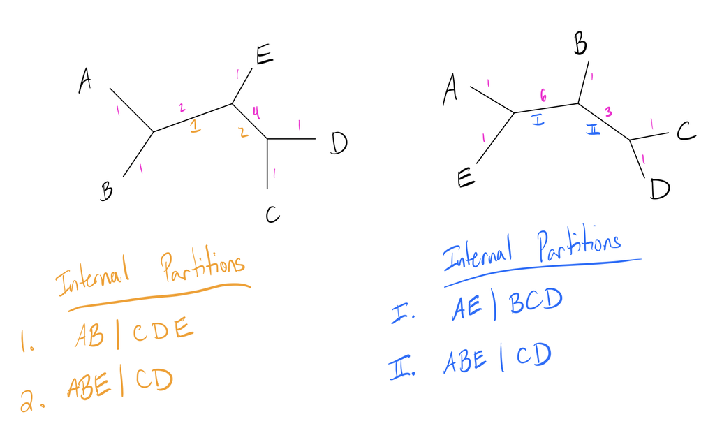

The advantages of this over RF distance is that it can incorporate branch lengths in addition to topology, which allows it to downweight small differences in topology and upweight large differences.

#### R Implementation

```r
KF_dist_external <- function(dend1, dend2){
  tf <- tempfile()
  WriteDendrogram(dend1, file=tf, quoteLabels=FALSE)
  predTree1 <- read.tree(tf)

  tf <- tempfile()
  WriteDendrogram(dend2, file=tf, quoteLabels=FALSE)
  predTree2 <- read.tree(tf)

  return(dist.topo(predTree1, predTree2, method='score'))
}

RF_dist_external(UPGMAtree, NJtree)
```

[output not shown]

```
##       tree1
## tree2    12
```

```r
RF_dist_external(UPGMAtree, MPtree)
```

```
##       tree1
## tree2    16
```

```r
RF_dist_external(NJtree, MPtree)
```

```
##       tree1
## tree2    12
```

### Manual Implementations

I wrote implementations of both distances from scratch to illustrate how these functions are working under the hood. Note that external packages incorporate some optimizations I didn’t implement that lead to different results.

#### Helper functions

This code block contains several helper functions and is compressed by default. Click “Code” to show this content.

```r
flatdendrapply <- function(dend, NODEFUN, LEAFFUN=NODEFUN, INCLUDEROOT=TRUE, ...){
  ## Applies a function to each node (internal and leaf) of the tree
  ## Returns a flat list
  val <- lapply(dend,
                \(x){
                  if (is.null(attr(x, 'leaf'))){
                    v <- list(NODEFUN(x, ...))
                    for ( child in x ) v <- c(v, Recall(child))
                    return(v)
                  }
                  else if (!is(LEAFFUN, 'function'))
                    return(list())
                  else
                    return(list(LEAFFUN(x, ...)))
                }
  )
  retval <- unlist(val, recursive=FALSE)
  if (!INCLUDEROOT)
    retval[[1]] <- NULL

  return(retval)
}

isLeaf <- function(dendNode){
  return(!is.null(attr(dendNode, 'leaf')) && attr(dendNode, 'leaf'))
}

equivPart <- function(set1, set2, fullset){
  # Checks if two partitions are equivalent
  inverseset1 <- fullset[!(fullset %in% set1)]
  return(setequal(set1,set2) || setequal(inverseset1, set2))
}

get_branch_length <- function(dendNode){
  ## Helper function for KF distance, gets partition and branch length
  ## of all branches Because of weirdness each node will return two values,
  ## the result just needs some slight post-processing
  ## (see KF_Distance function for example)
  if(isLeaf(dendNode)){
    return(0)
  }

  h <- attr(dendNode, 'height')
  n1 <- dendNode[[1]]
  n2 <- dendNode[[2]]
  c1 <- attr(n1, 'height')
  c2 <- attr(n2, 'height')

  if(isLeaf(n1))
    labs1 <- attr(n1, 'label')
  else
    labs1 <- unlist(n1)

  if (isLeaf(n2))
    labs2 <- attr(n2, 'label')
  else
    labs2 <- unlist(n2)

  l1 <- list(length=h-c1, part=labs1)
  l2 <- list(length=h-c2, part=labs2)
  return(list(l1, l2))
}
```

#### Robinson-Foulds Distance

```r
RF_Distance <- function(dend1, dend2){
  # Get all partitions
  part1 <- flatdendrapply(dend1, unlist, NULL)
  part2 <- flatdendrapply(dend2, unlist, NULL)
  allmembers <- unique(c(unlist(dend1), unlist(dend2)))

  # Calculate tree distance
  A <- B <- 0
  for ( i in seq_along(part1))
    A <- A + !any(sapply(part2, \(x) equivPart(part1[[i]], x, allmembers)))

  for ( i in seq_along(part2))
    B <- B + !any(sapply(part1, \(x) equivPart(part2[[i]], x, allmembers)))

  # This implementation normalizes to get a distance out of 1
  return((A+B) / (length(part1) + length(part2)))
}
```

#### Kuhner-Felsenstein Distance

```r
KF_Distance <- function(dend1, dend2){
  # Get all branch lengths and partitions
  part1 <- flatdendrapply(dend1, get_branch_length, NULL)
  part2 <- flatdendrapply(dend2, get_branch_length, NULL)

  # Each function call returns a length of list two, we just want the members
  part1 <- unlist(part1, recursive=FALSE)
  part2 <- unlist(part2, recursive=FALSE)

  # Root is split into two branches, need to combine
  part1[[1]]$length <- part1[[1]]$length + part1[[2]]$length
  part2[[1]]$length <- part2[[1]]$length + part2[[2]]$length
  part1[[2]] <- part2[[2]] <- NULL

  allmembers <- unique(c(unlist(dend1), unlist(dend2)))

  # For each
  treedist <- 0
  for ( i in seq_along(part1)){
    check <- sapply(part2, \(x) equivPart(part1[[i]]$part, x$part, allmembers))
    if (any(check)){
      loc <- which(check)
      treedist <- treedist + (part1[[i]]$length - part2[[loc]]$length)**2
    }
  }
  for ( i in seq_along(part2)){
    check <- sapply(part1, \(x) equivPart(part2[[i]]$part, x$part, allmembers))
    if (any(check)){
      loc <- which(check)
      treedist <- treedist + (part2[[i]]$length - part1[[loc]]$length)**2
    }
  }

  ## divided by two since duplicates will be added twice
  ## probably worth reworking at some point to avoid adding duplicates twice,
  ## this is just a quick fix
  return(sqrt(treedist/2))
}
```

```r
RFDists <- KFDists <- matrix(0, nrow=3, ncol=3)
rownames(RFDists) <- rownames(KFDists) <- colnames(RFDists) <- colnames(KFDists) <- c('UPGMA', 'NJ', 'MP')

RFDists[1,2] <- RFDists[2,1] <- RF_Distance(UPGMAtree, NJtree)
RFDists[1,3] <- RFDists[3,1] <- RF_Distance(UPGMAtree, MPtree)
RFDists[2,3] <- RFDists[3,2] <- RF_Distance(NJtree, MPtree)
KFDists[1,2] <- KFDists[2,1] <- KF_Distance(UPGMAtree, NJtree)
KFDists[1,3] <- KFDists[3,1] <- KF_Distance(UPGMAtree, MPtree)
KFDists[2,3] <- KFDists[3,2] <- KF_Distance(NJtree, MPtree)

RFDists
```

```
##           UPGMA        NJ        MP
## UPGMA 0.0000000 0.2608696 0.3478261
## NJ    0.2608696 0.0000000 0.2608696
## MP    0.3478261 0.2608696 0.0000000
```

```r
KFDists
```

```
##           UPGMA        NJ        MP
## UPGMA 0.0000000 0.9712953 1.0081297
## NJ    0.9712953 0.0000000 0.4130997
## MP    1.0081297 0.4130997 0.0000000
```

### Other Metrics

These are two commonly used metrics, but many more are implemented in the `TreeDist` package. Notable recent tree distance measures include:

- `TreeDist::TreeDistance` methods, using generalized RF distance from Smith (2020)
- `TreeDist::JaccardRobinsonFoulds` and `TreeDist:NyeSimilarity`, both generalized RF distances.
- `TreeDist::KendallColijn`, a distance that measures difference in path lengths between pairs of leaves
- `TreeDist::MASTSize`, a distance that measures the largest agreement subtree between two trees